# Problem Statement

With growing technology use and the availability of social media, such as twitter, people are able to connect and communicate quicker than ever before.

The goal of this notebook is to classify whether a tweet (texts) is related to disaster event or not using deep learning methods.

# Packages

```python
import string
import re
import urllib
import zipfile

import pandas as pd
import numpy as np

import matplotlib.pyplot as plt
import seaborn as sns

import tensorflow as tf
from tensorflow import keras
from tensorflow.keras import models
from tensorflow.keras import layers
from tensorflow.keras import metrics
from tensorflow.keras import regularizers
from tensorflow.keras import optimizers
from tensorflow.keras.preprocessing.text import Tokenizer
from tensorflow.keras.preprocessing.sequence import pad_sequences
```

# Data Description

We are given about 10,000 tweets (sentences made from people) that were hand classified with a label of 1 for a real disaster and 0 otherwise. The data is split between training and test with about 7,613 samples for the training set and 3,263 samples for the testing set.

Below is a description of the features given

| Columns | Description |
| --- | --- |
| id | (int) Unique ID for every tweet |
| keyword | (text) Main word from the text, but this field may also be missing |
| location | (text) Location the tweet was sent. May also be blank |
| text | (text) The tweet itself |
| target | {0,1} Boolean on whether the tweet is related to a disaster or not |

Data Provider: Figure Eight Inc.

Original Data Source: Data For Everyone

# EDA

```python
train = pd.read_csv('/kaggle/input/nlp-getting-started/train.csv')
test = pd.read_csv('/kaggle/input/nlp-getting-started/test.csv')

print(f'Total Training Size: {train.shape[0]:,}')
print(f'Total Test Size: {test.shape[0]:,}')
```

```
Total Training Size: 7,613
Total Test Size: 3,263
```

```python
# Inspection of our data
train.head(10)
```

|  | id | keyword | location | text | target |
| --- | --- | --- | --- | --- | --- |
| 0 | 1 | NaN | NaN | Our Deeds are the Reason of this #earthquake M... | 1 |
| 1 | 4 | NaN | NaN | Forest fire near La Ronge Sask. Canada | 1 |
| 2 | 5 | NaN | NaN | All residents asked to 'shelter in place' are ... | 1 |
| 3 | 6 | NaN | NaN | 13,000 people receive #wildfires evacuation or... | 1 |
| 4 | 7 | NaN | NaN | Just got sent this photo from Ruby #Alaska as ... | 1 |
| 5 | 8 | NaN | NaN | #RockyFire Update => California Hwy. 20 closed... | 1 |
| 6 | 10 | NaN | NaN | #flood #disaster Heavy rain causes flash flood... | 1 |
| 7 | 13 | NaN | NaN | I'm on top of the hill and I can see a fire in... | 1 |
| 8 | 14 | NaN | NaN | There's an emergency evacuation happening now ... | 1 |
| 9 | 15 | NaN | NaN | I'm afraid that the tornado is coming to our a... | 1 |

```python
# Manuall Inspect Disaster and Non Disaster Tweets
n = 5

print('Non-Disaster','\n','-'*80)
for _ in range(n):
    i = np.random.choice(train[train['target']==0].index,1)[0]
    print(train.loc[i,'text'],'\n')

print('Disaster','\n','-'*80)
for _ in range(n):
    i = np.random.choice(train[train['target']==1].index,1)[0]
    print(train.loc[i,'text'],'\n')
```

```
Non-Disaster
 --------------------------------------------------------------------------------
@MeekMill is w(rec)k league ball @Drake is Olympic level body bagging him like his career was nothing #trollingtilMeekdiss

ball has no curfew https://t.co/SG1FTKaEgq

Dont even come if you worried about curfew #BC19

Twister was fun https://t.co/qCT6fb8wOn

sorry but that mousse inundation was fuckin hilarious https://t.co/tUai0ZwGXU

Disaster
 --------------------------------------------------------------------------------
Boy saves autistic brother from drowning: A nine-year-old in Maine dove into a pool to save his autistic brother from drowning

Parker Ridge Fact Sheet Aug 6 2015 (Parker Ridge Wildfire): Information Phone: 208-267-6773 Email: pa... http://t.co/ezEIsaSm0C #IDFire

24 killed in two simultaneous rail crash as acute floods derail the two trains #India #mumbai... http://t.co/4KBWPCmMbM

Ton of smoke coming out of one of the new apartment buildings at 160 Ross in Auburn. Several fire trucks on scene. http://t.co/AHVYmSQHqC

#Myanmar  Displaced #Rohingya at #Sittwe point of no return http://t.co/qegMRhSms2  #Prison like conditions #genocide @IHHen @MSF @Refugees
```

```python
# How many missing data do we have for each column
missing = train.isnull().sum()
missing
```

```
id             0
keyword       61
location    2533
text           0
target         0
dtype: int64
```

```python
# Percentage missing
missing/train.shape[0]
```

```
id          0.000000
keyword     0.008013
location    0.332720
text        0.000000
target      0.000000
dtype: float64
```

We have about 0.8% of missing values for keywords and 33% missing for locations. In this case we should opt for removing location as a feature as there are too many missing values.

```python
# Find all the unique types of characters used
unique_char = set(train['text'].str.lower().sum())
print('Set of Characters:',unique_char)

# We want to remove all the unique characters that is not in the standard alphabet
char_to_remove = list(unique_char-set(string.ascii_lowercase))
print('Characters to be removed:',char_to_remove)
```

```
Set of Characters: {'«', 'w', 'ã', '\x89', 'o', 'e', 'l', 'n', 'ó', '£', 'ç', '\n', 'j', 'r', 'a', 'y', '÷', 's', 'ò', 'z', 'â', 'm', 'ê', 'u', '¼', '¨', 'd', 'ü', '´', 'g', 'h', '\x9d', 'f', '¡', 'q', 'ñ', 'ï', 'û', '¤', 'ª', 'x', '©', '¬', 'b', 'v', 'k', '\\', 't', 'ì', 'è', 'p', 'c', ' ', 'i'}
Characters to be removed: ['«', 'ã', '\x89', 'ó', '£', 'ç', '\n', '÷', 'ò', 'â', 'ê', '¼', '¨', '´', 'ü', '\x9d', '¡', 'ñ', 'ï', 'û', '¤', 'ª', '©', '¬', '\\', 'ì', 'è', ' ']
```

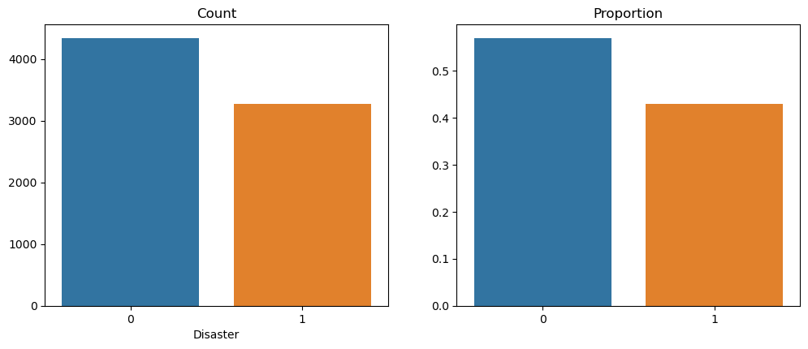

```python
# What is the distribution of our classes
class_count = train['target'].value_counts().to_frame().T

# Plot the counts and proportion of each class
fig,axs = plt.subplots(1,2,figsize=(12,4.5))

sns.barplot(data=class_count,ax=axs[0])
axs[0].set_title('Count')
axs[0].set_xlabel('Disaster')

sns.barplot(data=class_count/class_count.sum().sum(),ax=axs[1])
axs[1].set_title('Proportion')
axs[0].set_xlabel('Disaster')

plt.show();
```

We can see there is a slight class imbalance, approximately 60% of tweets are not related to a real disaster while 40% of tweets are. This suggests class balancing techniques may be helpful, but given the difference is not too large, we will initially skip it.

Next we will start looking at whether there are distinguishing features between disaster and non disaster tweets.

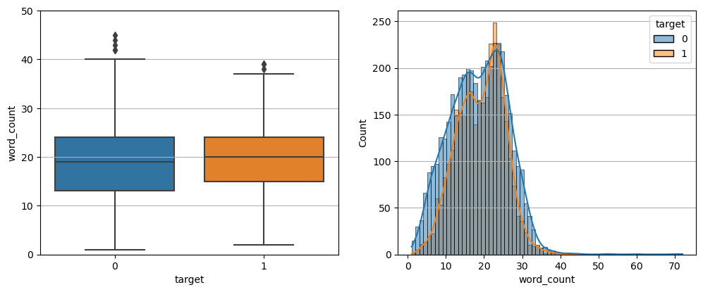

```python
# Are there a difference in word count
train['word_token'] = train['text'].apply(lambda x: word_tokenize(x))
train['word_count'] = train['word_token'].apply(lambda x: len(x))

# Boxplot of tweets
fig,axs = plt.subplots(1,2,figsize=(12,4.5))

# Boxplot
sns.boxplot(data=train,x='target',y='word_count',ax=axs[0])
axs[0].set_ylim(0,50)
axs[0].grid(axis='y')

# Distribution of word counts
sns.histplot(data=train,x='word_count',hue='target',ax=axs[1],kde=True)
axs[1].grid(axis='y')

plt.show();
```

There doesn't seem to be a large discrepancy between disaster tweets and non-disaster tweets in terms of the number of word counts.

#### Summary of EDA:

- We opt to remove the location feature as there are 33% missing data
- 0.8% of keyword are missing. Though not lots we will opt to remove it as it is unclear if it'll always be available.
- Slight difference class counts between non-disaster and disaster at about 60%/40% respectively.
- No distinguishing discrepancy between the number of words used between disaster and non-disaster tweets
- Text data needs to be cleaned of punctuations, etc.

Based on the above EDA analysis, we will opt to only use the text data, but will have to first clean the text data. Then we wil be using word embeddings to transform our text to matrix form and then apply our model, RNN, to this.

# Preprocessing

```python
def clean_text(text):

    # Lower case
    clean = text.lower()

    # Remove punctuations
    clean = re.sub('['+string.punctuation+']','',clean)

    # Remove numbers as they are generic
    clean = re.sub('[\d+]','',clean)

    # Remove trailing white spaces
    clean = clean.strip()

    # Remove any double white spaces
    clean = re.sub('  ','',clean)

    # Remove these special characters from earlier
    clean = re.sub(r'[«ã\x89ó£ç\n÷òâê¼¨´ü\x9d¡ñïû¤ª©¬\\ìè]','',clean)

    return clean

def preprocess(data, max_length=None, tokenizer=None):
    data['clean_text'] = data['text'].apply(lambda x: clean_text(x))

    if not tokenizer:
        tokenizer = Tokenizer()
        tokenizer.fit_on_texts(data['clean_text'])

    sequences = tokenizer.texts_to_sequences(data['clean_text'])

    sequences = pad_sequences(sequences,padding='post',maxlen=max_length)

    return sequences, tokenizer.word_index, tokenizer
```

```python
# Create our training data
X_train, word_index, tokenizer = preprocess(train)
y_train = train['target'].values

max_length = X_train[0].shape[0]

# Prep the test data
X_test,_,_ = preprocess(test,max_length,tokenizer)
```

#### Word Embedding

```python
# Download the pre-trained embeddings
url = 'https://huggingface.co/stanfordnlp/glove/resolve/main/glove.6B.zip'
glove_path = '/kaggle/working/glove.6B.zip'
urllib.request.urlretrieve(url, glove_path)

# Unzip the file
zip_file = '/kaggle/working/glove.6B.zip'
directory = '/kaggle/working/'
with zipfile.ZipFile(zip_file, 'r') as zip_ref:
    zip_ref.extractall(directory)
```

```python
def get_glove_embeds(filename):
    embeddings = {}
    with open(filename, 'r', encoding='utf-8') as f:
        for line in f:
            values = line.split()
            word = values[0]
            vector = np.asarray(values[1:], dtype='float32')
            embeddings[word] = vector
    return embeddings

glove_filename = '/kaggle/working/glove.6B.100d.txt'
glove_embed = get_glove_embeds(glove_filename)
```

# Model Architecture

We will use a simple RNN and try to fine tune the model to evaluate the effectiveness of the simplest available model.

```python
def plot_metrics(history,metric,title=None,val_plot=True):
    fig,axs = plt.subplots(1,1,figsize=(5,3))

    # Plot Loss
    axs.plot(
        range(len(history[metric])),
        history[metric],
        label='training',
        color = 'black'
    )
    if val_plot:
        axs.plot(
            range(len(history[metric])),
            history[f'val_{metric}'],
            label='validation',
            color='red'
        )

    # Aesthetics
    axs.legend()
    axs.grid(axis='y')
    axs.set_title(title)
    axs.set_xlabel('epoch')

    plt.show()
```

```python
# Global training params
BATCH_SIZE = 64
VAL_SIZE = 0.2
MAX_EPOCH = 10
```

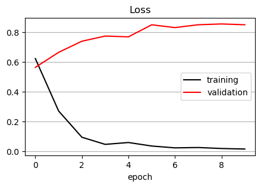

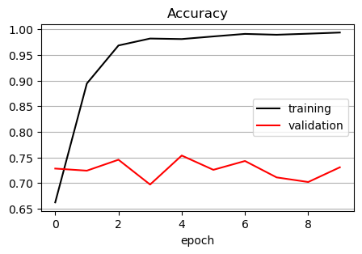

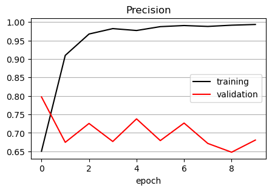

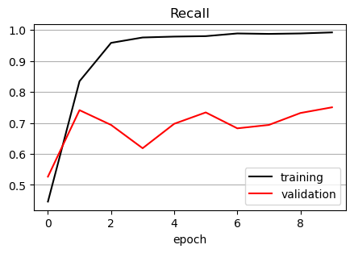

```python
# The model
model = models.Sequential()

model.add(layers.Embedding(len(word_index)+1, 128, input_length=X_train.shape[1]))
model.add(layers.SimpleRNN(128))
model.add(layers.Dense(1,activation='sigmoid'))

metrics_ = [metrics.Recall(name='recall'),metrics.Precision(name='precision'),'accuracy']
model.compile(loss='binary_crossentropy', optimizer='adam', metrics=metrics_)

# Training
model_fit = model.fit(X_train, y_train, epochs=MAX_EPOCH, validation_split=VAL_SIZE, batch_size=BATCH_SIZE)

# Evaluation
plot_metrics(model_fit.history, 'loss','Loss')
plot_metrics(model_fit.history, 'accuracy','Accuracy')
plot_metrics(model_fit.history, 'precision','Precision')
plot_metrics(model_fit.history, 'recall','Recall')
```

While the training loss and accuracy shows strong results, the validation loss and accuracy shows the opposite. This is a good indication our model has been heavily overfitted.

In order for us to combat the overfitting we attempt multiple methods but highlight the key differences between our initial and our final model:

- Decreased the learning rate to 1e-4 from 1e-3. Although the training data did not indicate the learning rate was too high, we adjusted the learning rate around to see which method performed best.
- A dropout layer was added with 20% dropout. This helps by forcing the model to rely less on any specific set of parameters.
- Used an L1 regularizer, we also tested an L2 regularizer but found that the L1 regularizer performed better. This likely performed better because of the nature of our data. Specific words likely had more meaning and with L1 regularizer, it inherently feature selects or selects the more important words related to the sentiment of the tweet.

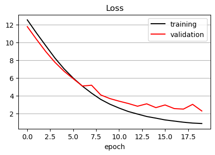

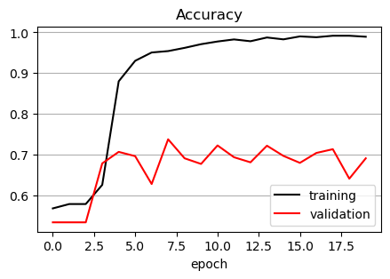

```python
# The model
learning_rate = 1e-4
MAX_EPOCH = 20

model = models.Sequential()

model.add(layers.Embedding(len(word_index)+1, 128, input_length=X_train.shape[1]))
model.add(layers.SimpleRNN(128, activation='relu',kernel_regularizer=regularizers.l1()))
model.add(layers.Dropout(0.2))
model.add(layers.Dense(1,activation='sigmoid'))

metrics_ = [metrics.Recall(name='recall'),metrics.Precision(name='precision'),'accuracy']
model.compile(loss='binary_crossentropy', optimizer=optimizers.Adam(learning_rate), metrics=metrics_)

# Training
model_fit = model.fit(X_train, y_train, epochs=MAX_EPOCH, validation_split=VAL_SIZE, batch_size=BATCH_SIZE)

# Evaluation
plot_metrics(model_fit.history, 'loss','Loss')
plot_metrics(model_fit.history, 'accuracy','Accuracy')
```

From the above we still see some evidence of overfitting, but overall an improvement from our initial model as the validation loss decreases with epochs.

```python
# Make prediction
predictions = np.round(model.predict(X_test))

# Create Submission file
submission = pd.DataFrame()
submission['id'] = test['id']
submission['target'] = predictions
submission['target'] = submission['target'].astype(int)
submission.to_csv('/kaggle/working/submission.csv',index=False)
print('Done')
```

```
Done
```

# Results and Analysis

Our initial model proved to have very poor performance initially. We were able to see this through the diagnostic plots of loss vs epoch and accuracy vs epoch. In the loss vs epoch plot, we noticed as we increased the epoch, the training loss was decrease while the validation loss was increasing which was a clear sign of overfitting.

In order for us to combat the overfitting we attempted adjusting the hyperparameter. Difference between our final model and the our initial model highlights are below:

- Decreased the learning rate to 1e-4 from 1e-3. Although the training data did not indicate the learning rate was too high, we adjusted the learning rate around to see which method performed best.
- A dropout layer was added with 20% dropout. This helps by forcing the model to rely less on any specific set of parameters.
- Used an L1 regularizer, we also tested an L2 regularizer but found that the L1 regularizer performed better. This likely performed better because of the nature of our data. Specific words likely had more meaning and with L1 regularizer, it inherently feature selects or selects the more important words related to the sentiment of the tweet.
- Increased the number of epoch to ensure convergence of the loss

Our final model was able to produce a prediction score of about 0.74 on the test set.

# Conclusion

Going forward to improve this model, we should look at further hyperparameter tuning of the model as there is still evidence of overfitting. Adjusting the model for complexity would likely only lead to more overfitting unless we add new layers such as drop out to help with this. Alternatively to get further improvement in this dataset, other models could be explored that are better fit to understand context such as BERT model.

# References

- https://www.kaggle.com/code/abhinand05/bert-for-humans-tutorial-baseline-version-2/notebook